# Lab 1: Only One Test

- Gesamten Code zeigen
- Gesamten Code verbergen
- Quellcode anzeigen

Bootstrap & Permutationstest mit dem infer-Paket

Autor:in

Prof. Dr. Jörg Schoder

Veröffentlichungsdatum

17. März 2026

## Lernziele und Überblick

**HinweisLernziele dieses Labs**

- Bootstrap-Konfidenzintervall für den Regressionskoeffizienten $\hat\beta_{\text{age}}$ berechnen
- Permutationstest auf Unabhängigkeit durchführen
- Beide Methoden mit dem traditionellen t-Test vergleichen
- Das Konzept **„Only One Test”** verstehen und anwenden

**Modell:**
$$\widehat{\log(\text{mv})} = \hat\beta_0 + \hat\beta_1 \cdot \text{age}$$

**Die infer-Pipe** folgt stets demselben Ablauf:

```
Daten
  %>% specify()      # Welche Variablen?
  %>% hypothesize()  # Nullhypothese (nur bei Test, nicht bei Bootstrap-KI)
  %>% generate()     # Bootstrap oder Permutation
  %>% calculate()    # Teststatistik berechnen
  %>% visualize()    # Visualisieren
```

**TippZeitplanung**

⏱ **40 Minuten** — Pflichtaufgaben (A1–A3) zuerst, Bonusaufgaben wenn Zeit bleibt.

## Schritt 1: Punktschätzer

Der erste Schritt ist immer die Berechnung des **beobachteten Koeffizienten** — des Punktschätzers aus den vorliegenden Daten.

```r
obs_slope <- tbl_buli %>%
               specify(log_value ~ age) %>%
               calculate(stat = "slope")
obs_slope
```

```
Response: log_value (numeric)
Explanatory: age (numeric)
# A tibble: 1 × 1
    stat
   <dbl>
1 0.0261
```

**TippZur Interpretation**

- Was bedeutet dieser Wert inhaltlich? (Denken Sie an die Log-Transformation!)
- Handelt es sich um einen Populations- oder Stichprobenparameter?
- Warum reicht dieser eine Wert alleine nicht für eine verlässliche Aussage?

## Schritt 2: Bootstrap-Verteilung

Beim Bootstrapping ziehen wir **1000× mit Zurücklegen** aus den vorhandenen Daten und berechnen jedes Mal den Regressionskoeffizienten. Die Verteilung dieser 1000 Koeffizienten approximiert die Stichprobenverteilung.

**Wichtig:** Beim Bootstrap zur KI-Schätzung verwenden wir **kein** `hypothesize()` — wir machen keine Annahme über die Nullhypothese, sondern schätzen die Variabilität des Koeffizienten.

**Code anzeigen**

```r
set.seed(2024)

boot_dist <- tbl_buli %>%
               specify(log_value ~ age) %>%
               # KEIN hypothesize() — wir schätzen, nicht testen
               generate(reps = 1000, type = "bootstrap") %>%
               calculate(stat = "slope")
```

**Code anzeigen**

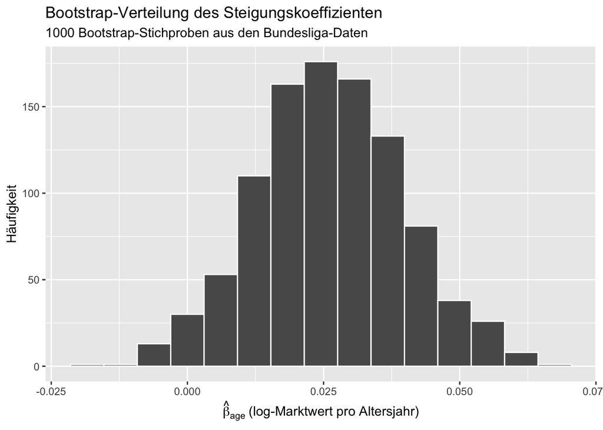

```r
visualize(boot_dist) +
  labs(
    title    = "Bootstrap-Verteilung des Steigungskoeffizienten",
    subtitle = "1000 Bootstrap-Stichproben aus den Bundesliga-Daten",
    x        = expression(hat(beta)[age]~"(log-Marktwert pro Altersjahr)"),
    y        = "Häufigkeit"
  )
```

**HinweisWas zeigt diese Verteilung?**

Die Breite der Bootstrap-Verteilung entspricht dem **Standardfehler** des Koeffizienten. Je schmaler die Verteilung, desto präziser die Schätzung.

## Schritt 3: Konfidenzintervall

Aus der Bootstrap-Verteilung lassen sich Konfidenzintervalle auf zwei Arten berechnen:

**Perzentilmethode**

Die einfachste Methode: die mittleren 95% der Bootstrap-Verteilung.

**Code anzeigen**

```r
ci_pct <- boot_dist %>%
            get_confidence_interval(
              type  = "percentile",
              level = 0.95
            )
ci_pct
```

```
# A tibble: 1 × 2
   lower_ci upper_ci
      <dbl>    <dbl>
1 -0.000917   0.0531
```

**Standardfehler-Methode**

Verwendet den Bootstrap-Standardfehler und zentriert das Intervall um den beobachteten Schätzer.

**Code anzeigen**

```r
ci_se <- boot_dist %>%
           get_confidence_interval(
             type           = "se",
             point_estimate = obs_slope,
             level          = 0.95
           )
ci_se
```

```
# A tibble: 1 × 2
   lower_ci upper_ci
      <dbl>    <dbl>
1 -0.000514   0.0527
```

**Visualisierung**

**Code anzeigen**

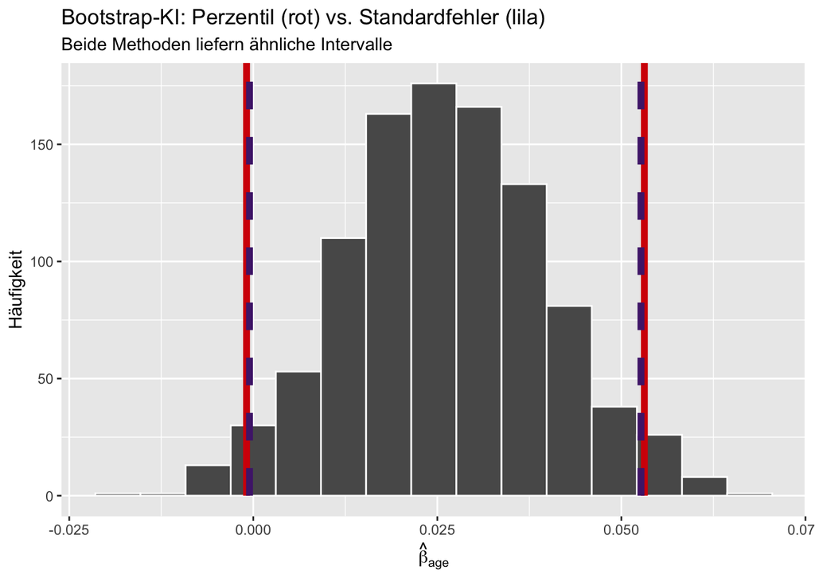

```r
visualize(boot_dist) +
  shade_confidence_interval(
    endpoints = ci_pct,
    fill      = NULL,
    linetype  = "solid",
    color     = "#D50006"
  ) +
  shade_confidence_interval(
    endpoints = ci_se,
    fill      = NULL,
    linetype  = "dashed",
    color     = "#502479"
  ) +
  labs(
    title    = "Bootstrap-KI: Perzentil (rot) vs. Standardfehler (lila)",
    subtitle = "Beide Methoden liefern ähnliche Intervalle",
    x        = expression(hat(beta)[age]),
    y        = "Häufigkeit"
  )
```

**Interpretation**

**TippFragen zur Diskussion**

- Enthält das Konfidenzintervall die Null?
- Was bedeutet das für die Signifikanz des Alterseffekts?
- Warum sind Perzentil- und SE-Methode ähnlich aber nicht identisch?
- Was bedeutet “95% Konfidenz” **exakt**?

**WichtigKorrekte Interpretation**

Bei wiederholter Stichprobenziehung würden 95% der so berechneten Konfidenzintervalle den wahren Parameter $\beta_{\text{age}}$ enthalten.

**Nicht:** „Mit 95% Wahrscheinlichkeit liegt der wahre Wert in diesem Intervall.”

## Schritt 4: Permutationstest

Der Permutationstest simuliert eine **Welt ohne Zusammenhang** (die Null-Welt): die Alterswerte werden zufällig neu den Spielern zugeordnet, so dass jeder systematische Zusammenhang zerstört wird.

**Code anzeigen**

```r
set.seed(2024)

null_dist <- tbl_buli %>%
               specify(log_value ~ age) %>%
               hypothesize(null = "independence") %>%
               generate(reps = 1000, type = "permute") %>%
               calculate(stat = "slope")

# p-Wert berechnen
p_val <- null_dist %>%
           get_p_value(obs_stat   = obs_slope,
                       direction  = "two-sided")
p_val
```

```
# A tibble: 1 × 1
  p_value
    <dbl>
1   0.034
```

**Code anzeigen**

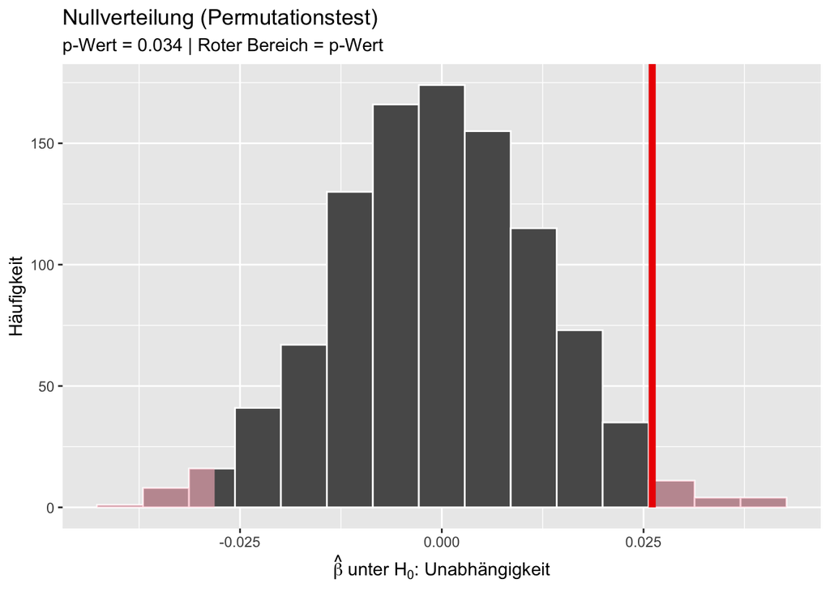

```r
null_dist %>%
  visualize() +
  shade_p_value(obs_stat  = obs_slope,
                direction = "two-sided") +
  labs(
    title    = "Nullverteilung (Permutationstest)",
    subtitle = glue::glue("p-Wert = {round(p_val$p_value, 4)} | Roter Bereich = p-Wert"),
    x        = expression(hat(beta)~"unter H"[0]*": Unabhängigkeit"),
    y        = "Häufigkeit"
  )
```

**HinweisWas sehen wir hier?**

## Schritt 5: Vergleich mit dem traditionellen t-Test

**Code anzeigen**

```r
reg_buli <- tbl_buli %>%
              lm(log_value ~ age, data = .)

reg_buli %>%
  get_regression_table() %>%
  gt() %>%
  fmt_number(columns = c(estimate, std_error, statistic,
                         p_value, lower_ci, upper_ci),
             decimals = 4) %>%
  tab_style(
    style     = cell_fill(color = "#fff8e1"),
    locations = cells_body(rows = term == "age")
  ) %>%
  tab_options(table.font.size = "14px") %>%
  tab_footnote("Gelb markiert: Koeffizient für Alterseffekt")
```

| term | estimate | std_error | statistic | p_value | lower_ci | upper_ci |
| --- | --- | --- | --- | --- | --- | --- |
| intercept | 13.9810 | 0.3800 | 36.8220 | 0.0000 | 13.2350 | 14.7270 |
| age | 0.0260 | 0.0130 | 2.0050 | 0.0450 | 0.0010 | 0.0520 |

Gelb markiert: Koeffizient für Alterseffekt